# Predicting NBA Player Success

Final Project  
Data Science 2 with R (STAT 301-2)

Author

Noah Short

Published

March 9, 2024

**Github Repo Link**

[My Final Project Repo](https://github.com/stat301-2-2024-winter/final-project-2-noahshort.git)

## Introduction

This project aims to predict an NBA player’s Win’s Above Replacement (WAR) in the next season using statistics from the previous one and biographical information. Wins Above Replacement is a relatively new statistic in many sports that uses a laughingly complicated formula to calculate a player’s value in a season or across a career in terms of the number of wins they added to the team above a typical “replacement” player. I would like to predict this variable to investigate how strongly a player’s performance in the previous year is connected to the next year’s.

From my own experience as a fan, it seems that outside of the top 20-30 players in the NBA, players seem to have a “revolving door” type of experience with success: constantly fluctuating between stretches of stardom and disappointment. This leads me to hypothesize that this prediction may be challenging outside of the elite players.

I use two data sources in this project. Each data source contains observations of a player’s statistics in a single season accompanied by some biographical information. The first data source is heavier on the statistics and comes from Fivethirtyeight. It contains their “Raptor” data, which they describe as “a plus-minus statistic that measures the number of points a player contributes to his team’s offense and defense per 100 possessions, relative to a league-average player” (Silver). The other data source is a public data set on Kaggle with some more basic statistics as well as information on draft position and a player’s home country.

The data overlaps between 1997 and 2022, so the final workable data set for my purposes contains observations of all players between 1997 and 2021, as I cannot use 2022 data without the WAR metric from the following season.

## Data Overview

After wrangling and tidying the data, the final, workable data set contains 11,583 observations across 25 seasons.

One issue that arose when wrangling the data was the imputation of missing values for the final observation from a player’s career. It would not be accurate to simply impute with a zero, since many players end the year with a negative WAR yet remain in the NBA for long periods of time. I decided to impute in the pre-processing stage by taking the player’s WAR in the observed year, dividing by the median WAR for that season, and multiplying that ratio by the following season’s median WAR. This works as a linear continuation of the player’s trend compared to his competition, but assumes his playing level won’t taper off too heavily. Before imputation, the outcome variable had ~19% missingness, but this method drops that to zero. Below is a missingness report after imputation:

| variable | n_miss | pct_miss |
| --- | --- | --- |
| draft_number | 2049 | 17.6897177 |
| college | 5 | 0.0431667 |
| pace_impact | 1 | 0.0086333 |

The only variable with significant missingness is `draft_number`, or the exact position in the draft a player was chosen. I did not end up using this variable as a predictor, as a small difference in draft position does not make any tangible impact outside of the 1st selection (and only in some drafts!). I did use the `draft_round` variable, which is a factor with three levels: Round 1, Round 2, Undrafted. Figure 1 below shows the distribution of `draft round`.

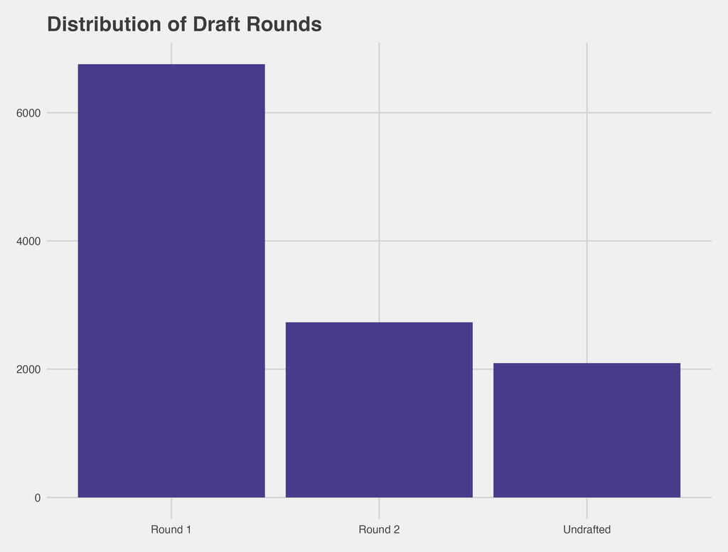

Figure 1: Class Imbalance of Players’ Draft Round

It is fairly obvious that there are far more players drafted in the 1st round and end up recording statistics in the NBA. However, given there are a plethora of other predictors in play to indicate success on the court, I am not concerned that the players drafted in the 1st round will skew the impacts of this variable. Two of the best and most tenured players in this data set (LeBron James and Manu Ginobili) were Undrafted and Round 2 selections, respectively.

### Target Variable Analysis

Getting to the target variable now, Figure 2 provides a plot of its distribution and the table below provides breakdown of its spread:

| skim_type | skim_variable | n_missing | complete_rate | numeric.mean | numeric.sd | numeric.p0 | numeric.p25 | numeric.p50 | numeric.p75 | numeric.p100 |
| --- | --- | --- | --- | --- | --- | --- | --- | --- | --- | --- |
| numeric | next_season_war_total | 0 | 1 | 1.863937 | 3.384864 | -6.649372 | -0.1328395 | 0.4963534 | 2.943884 | 28.52526 |

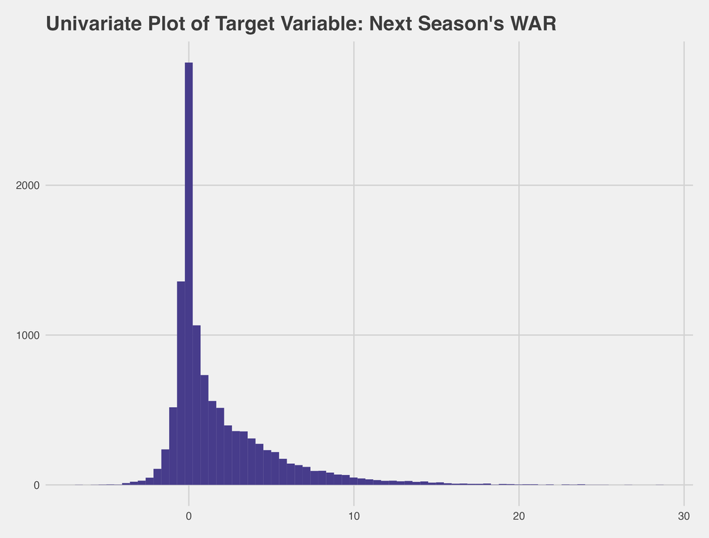

Figure 2: Histogram of Outcome Variable

The plot is unimodal with some skew. It is centered near zero which is nice, but I naturally looked for transformations to get it a bit more symmetrical, only to find most transformations only made things worse, as indicated in Figure 3.

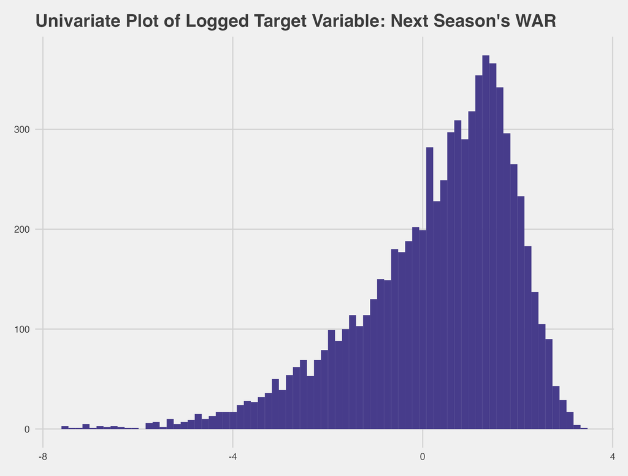

Figure 3: Histogram of Logged Outcome Variable

The plot is a bit more spread out, but the skew takes longer to taper off. Also, missing values are generated for all original values of 0. This led me to choose to leave the outcome variable untouched in this project.

### EDA of Predictors

I conducted a very baseline EDA of the predictor variables and their distributions with the outcome variable in `2.5_predictor_variable_analysis.R`. The notable takeaways are as follows:

- The predictor `war_total` will remain as-is, largely because I chose to leave the outcome variable unchanged and they are on the same scale since they are the same statistic.
- There is no concern with multicollinearity since the outcome variable is from the future, essentially unaffected by any of the predictors directly, including `war_total`.
- None of the numerical predictors need any transformation due to skew, most are roughly linear in their relationship with the target variable.
- `age`, `player_height`, and `player_weight` seem to have the weakest relationship with the outcome variable.

## Methods

### Prediction Problem

This project deals with a **regression** problem of attempting to predict the value of an NBA player’s season Wins Above Replacement (WAR) using data from the previous season.

### Data Split

The final data was split by season, with the 4 most recent seasons making up the test set and the 21 previous seasons making up the training set. This amounted to a roughly 82:18 split overall. With more than 11,500 observations, this put more than 2,000 observations in the testing set, which I felt was more than enough. The split was ordered by season because the natural use for a model like this is to attempt to predict a player’s WAR in a future season, so we should look at testing results the same way.

### Model Types

I used 6 different model types in this project:

**Null Model** - used baseline recipe

- Had its own baseline recipe simply using predictors found in both recipes
- Simplest form of model, expected to be the least accurate (which it was, by a lot)
- One single model

**Linear Model** - used lm recipes

- Simple OLS regression where each predictor gets a coefficient estimate
- Seeks to minimize the squared sum of residuals
- One single model

**Elastic Net Model** - used lm recipes

- Linear regression with varying `mixture` and `penalty` hyperparameters, which were both tuned.
- Mixture term is a scale from 0 to 1 and indicates how strong the model should be in fitting. Lower mixture means more reliance on the data itself, higher mixture means greater use of tools.
- Penalty term is a scale from 0 to 1 where 0 means the model is solely concerned with balancing out effects of multiple predictors, while 1 means the model is solely concerned with finding which predictors matter and which don’t.
- 2 parameters tuned using a regular grid over 5 levels each, so 25 different elastic net models were trained 30 times each, for 750 total trainings.

**K-Nearest Neighbors Model** - used lm recipes

- Flexible model that predicts the value of a new data point using the data points nearest the new one in each predictor.
- `neighbors` hyperparameter tuned: dictates how many neighbors to look at.
- Tuned over 5 levels using a regular grid, so 5 different KNN models were trained 30 times each, for 150 total trainings.

**Random Forest Model** - used rf recipes

- Decision tree-based model where many decision trees are ran through to get an estimate then averaged over.
- 2 hyperparamaters tuned: `min_n` and `mtry`. `trees` set to 500.
- `min_n` is the number of data points to split.
- `mtry` is the number of predictors to use in the decision trees.
- Both tuning parameters used a regular grid over 5 levels, so 25 different random forest models were trained 30 times each, for 750 total fits.

**Boosted Trees Model** - used rf recipes

### Recipes

I used 5 total recipes: 2 stats-heavy recipes (lm and rf), 2 biography-heavy recipes (lm and rf), and 1 baseline recipe.

In my recipes, I chose to limit the number of statistical predictors used because I felt many of them would overcomplicate the models. For example, I only wanted one metric for rebounding, so I used `reb` and omitted `drb_pct` and `orb_pct`. A true ‘kitchen sink’ recipe may be something to explore in later developments or modifications.

**Statistics-Heavy Recipes**

- Used the following predictors: `war_total`, `raptor_offense`, `raptor_defense`, `pts`, `reb`, `ast`, and `draft_round`
- Dummy encoded `draft_round` (used one-hot encoding for the tree-based recipe)
- Created an interaction term between `raptor_offense` and `pts` as well as `raptor_offense` and `ast` because points and assists both contribute positively to the RAPTOR statistic, as described earlier by Fivethirtyeight. These interactions were removed for the tree-based recipe
- Removed predictors with zero variance
- Normalized and scaled all numerical predictors

**Biography-Heavy Recipes**

- Used the following predictors: `war_total`, `pts`, `reb`, `ast`, `age`, `player_height`, `player_weight`, `draft_round`, `country`
- Dummy encoded `draft_round` and `country` (used one-hot encoding for the tree-based recipe)
- Created an interaction term between `player_weight` and `player_height`, but removed it for the tree-based recipe
- Removed predictors with zero variance
- Normalized and scaled all numerical predictors

**Baseline Recipe**

- Used the following predictors: `war_total`, `pts`, `reb`, `ast`, `draft_round`
- Dummy encoded `draft_round`
- Removed predictors with zero variance
- Normalized and scaled all numerical predictors

### Assessment Metric

My assessment metric is root mean squared error, or RMSE. With the outcome variable having a small total range of about 35, it will be easy to interpret in terms of the “root-squared number of wins” the models are off by.

## Model Building and Selection

I will start by going through the results of each model.

### Null Model

| .metric | .estimator | mean | n | std_err | .config |
| --- | --- | --- | --- | --- | --- |
| rmse | standard | 3.383457 | 30 | 0.0175505 | Preprocessor1_Model1 |

To be blunt, the null model stinks. Missing by a root-mean-squared 3.4 WAR is horrendous, given that NBA all-stars sometimes have 3.4 WAR at the all-star break. But, this is expected since it is just a null model that uses fewer predictors in its recipe.

### Linear Model

| .metric | .estimator | mean | n | std_err | .config |
| --- | --- | --- | --- | --- | --- |
| rmse | standard | 2.130733 | 30 | 0.0088889 | Preprocessor1_Model1 |

| .metric | .estimator | mean | n | std_err | .config |
| --- | --- | --- | --- | --- | --- |
| rmse | standard | 2.121061 | 30 | 0.0087236 | Preprocessor1_Model1 |

The stats-based model is shown first, followed by the bio-based one. Both models improve mightily from the null, and *spoiler alert* one of these ends up being the best model.

### Elastic Net Model

| penalty | mixture | .metric | .estimator | mean | n | std_err | .config |
| --- | --- | --- | --- | --- | --- | --- | --- |
| 0.0000000 | 0.2875 | rmse | standard | 2.130742 | 30 | 0.0089095 | Preprocessor1_Model06 |
| 0.0000000 | 0.2875 | rmse | standard | 2.130742 | 30 | 0.0089095 | Preprocessor1_Model07 |
| 0.0000100 | 0.2875 | rmse | standard | 2.130742 | 30 | 0.0089095 | Preprocessor1_Model08 |
| 0.0031623 | 0.2875 | rmse | standard | 2.130742 | 30 | 0.0089095 | Preprocessor1_Model09 |
| 0.0000000 | 0.0500 | rmse | standard | 2.130747 | 30 | 0.0088995 | Preprocessor1_Model01 |

| penalty | mixture | .metric | .estimator | mean | n | std_err | .config |
| --- | --- | --- | --- | --- | --- | --- | --- |
| 0.0000000 | 0.0500 | rmse | standard | 2.121466 | 30 | 0.0087602 | Preprocessor1_Model01 |
| 0.0000000 | 0.0500 | rmse | standard | 2.121466 | 30 | 0.0087602 | Preprocessor1_Model02 |
| 0.0000100 | 0.0500 | rmse | standard | 2.121466 | 30 | 0.0087602 | Preprocessor1_Model03 |
| 0.0031623 | 0.0500 | rmse | standard | 2.121466 | 30 | 0.0087602 | Preprocessor1_Model04 |
| 0.0000000 | 0.2875 | rmse | standard | 2.121600 | 30 | 0.0087691 | Preprocessor1_Model06 |

We see here that both the stats-based and bio-based models are very strong, and that lower penalty seems better while mixture can vary a bit. The bias towards a lower penalty makes sense, since these recipes require the model to juggle several different predictors.

### K-Nearest Neighbors Model

| neighbors | .metric | .estimator | mean | n | std_err | .config |
| --- | --- | --- | --- | --- | --- | --- |
| 15 | rmse | standard | 2.232388 | 30 | 0.0098125 | Preprocessor1_Model5 |
| 11 | rmse | standard | 2.269960 | 30 | 0.0099644 | Preprocessor1_Model4 |
| 8 | rmse | standard | 2.321142 | 30 | 0.0102311 | Preprocessor1_Model3 |
| 4 | rmse | standard | 2.489692 | 30 | 0.0109863 | Preprocessor1_Model2 |
| 1 | rmse | standard | 2.969546 | 30 | 0.0134839 | Preprocessor1_Model1 |

| neighbors | .metric | .estimator | mean | n | std_err | .config |
| --- | --- | --- | --- | --- | --- | --- |
| 15 | rmse | standard | 2.194199 | 30 | 0.0090302 | Preprocessor1_Model5 |
| 11 | rmse | standard | 2.222503 | 30 | 0.0090365 | Preprocessor1_Model4 |
| 8 | rmse | standard | 2.264285 | 30 | 0.0089560 | Preprocessor1_Model3 |
| 4 | rmse | standard | 2.407668 | 30 | 0.0095649 | Preprocessor1_Model2 |
| 1 | rmse | standard | 2.844875 | 30 | 0.0136374 | Preprocessor1_Model1 |

These models are a bit worse than the linear ones, but there is a clear trend in both cases that increasing the number of neighbors used improves the RMSE.

### Random Forest Model

| mtry | min_n | .metric | .estimator | mean | n | std_err | .config |
| --- | --- | --- | --- | --- | --- | --- | --- |
| 2 | 30 | rmse | standard | 2.132076 | 30 | 0.0089373 | Preprocessor1_Model17 |
| 2 | 21 | rmse | standard | 2.132627 | 30 | 0.0089952 | Preprocessor1_Model12 |
| 2 | 40 | rmse | standard | 2.132847 | 30 | 0.0091135 | Preprocessor1_Model22 |
| 4 | 40 | rmse | standard | 2.137260 | 30 | 0.0088883 | Preprocessor1_Model23 |
| 2 | 11 | rmse | standard | 2.137322 | 30 | 0.0090518 | Preprocessor1_Model07 |

| mtry | min_n | .metric | .estimator | mean | n | std_err | .config |
| --- | --- | --- | --- | --- | --- | --- | --- |
| 4 | 40 | rmse | standard | 2.122914 | 30 | 0.0090087 | Preprocessor1_Model23 |
| 4 | 30 | rmse | standard | 2.123145 | 30 | 0.0090981 | Preprocessor1_Model18 |
| 5 | 40 | rmse | standard | 2.123785 | 30 | 0.0087990 | Preprocessor1_Model24 |
| 4 | 21 | rmse | standard | 2.124941 | 30 | 0.0090242 | Preprocessor1_Model13 |
| 5 | 30 | rmse | standard | 2.124985 | 30 | 0.0087441 | Preprocessor1_Model19 |

These models are also very strong (comparatively) but the hyperparameters seem to vary all over the place, as in there is no clear trend to which values are best. This makes me think that if I was confined to a random forest model, I would want to use more levels with a random grid to see if I could “strike gold” per se.

### Boosted Tree Model

| mtry | min_n | learn_rate | .metric | .estimator | mean | n | std_err | .config |
| --- | --- | --- | --- | --- | --- | --- | --- | --- |
| 5 | 18 | 0.0520592 | rmse | standard | 2.534867 | 30 | 0.0141804 | Preprocessor1_Model1 |
| 6 | 36 | 0.0146035 | rmse | standard | 3.202728 | 30 | 0.0170479 | Preprocessor1_Model5 |
| 5 | 5 | 0.0100104 | rmse | standard | 3.330843 | 30 | 0.0174817 | Preprocessor1_Model3 |
| 8 | 32 | 0.0069445 | rmse | standard | 3.419519 | 30 | 0.0176833 | Preprocessor1_Model4 |
| 2 | 28 | 0.0000194 | rmse | standard | 3.647180 | 30 | 0.0184770 | Preprocessor1_Model2 |

| mtry | min_n | learn_rate | .metric | .estimator | mean | n | std_err | .config |
| --- | --- | --- | --- | --- | --- | --- | --- | --- |
| 5 | 18 | 0.0520592 | rmse | standard | 2.543525 | 30 | 0.0138126 | Preprocessor1_Model1 |
| 6 | 36 | 0.0146035 | rmse | standard | 3.208304 | 30 | 0.0169219 | Preprocessor1_Model5 |
| 5 | 5 | 0.0100104 | rmse | standard | 3.338580 | 30 | 0.0174425 | Preprocessor1_Model3 |
| 8 | 32 | 0.0069445 | rmse | standard | 3.419920 | 30 | 0.0177901 | Preprocessor1_Model4 |
| 2 | 28 | 0.0000194 | rmse | standard | 3.647261 | 30 | 0.0184779 | Preprocessor1_Model2 |

### Differences Between Recipes

The differences are not large, but in all model types besides boosted tree, the biography-heavy recipe performs slightly better than the stats-heavy recipe.

### And the Winner is…

| model | mean | .metric | n | std_err | penalty | mixture | neighbors | mtry | min_n | learn_rate |
| --- | --- | --- | --- | --- | --- | --- | --- | --- | --- | --- |
| lm bio | 2.121061 | rmse | 30 | 0.0087236 | NA | NA | NA | NA | NA | NA |
| elastic net bio | 2.121466 | rmse | 30 | 0.0087602 | 0 | 0.0500 | NA | NA | NA | NA |
| random forest bio | 2.122914 | rmse | 30 | 0.0090087 | NA | NA | NA | 4 | 40 | NA |
| lm stats | 2.130733 | rmse | 30 | 0.0088889 | NA | NA | NA | NA | NA | NA |
| elastic net stats | 2.130742 | rmse | 30 | 0.0089095 | 0 | 0.2875 | NA | NA | NA | NA |
| random forest stats | 2.132076 | rmse | 30 | 0.0089373 | NA | NA | NA | 2 | 30 | NA |
| knn bio | 2.194199 | rmse | 30 | 0.0090302 | NA | NA | 15 | NA | NA | NA |
| knn stats | 2.232388 | rmse | 30 | 0.0098125 | NA | NA | 15 | NA | NA | NA |
| boosted trees stats | 2.534867 | rmse | 30 | 0.0141804 | NA | NA | NA | 5 | 18 | 0.0520592 |
| boosted trees bio | 2.543525 | rmse | 30 | 0.0138126 | NA | NA | NA | 5 | 18 | 0.0520592 |
| null | 3.383457 | rmse | 30 | 0.0175505 | NA | NA | NA | NA | NA | NA |

The best-performing model was the linear model using the biography-heavy recipe.

This result surprised me initially, as the best models seemed to always be random forest or boosted tree models in labs for class. However, when thinking further I realized that my regression problem and recipe setup are very conducive to a simple OLS problem; one statistical metric that comes from an amalgam of statistics and background information each fighting for the most accurate coefficient to predict success.

## Testing and Analyzing the Linear Model

Fitting the linear model from above to the testing set yielded the following metrics:

| .metric | .estimator | .estimate |
| --- | --- | --- |
| rmse | standard | 1.9941976 |
| rsq | standard | 0.5677863 |
| mae | standard | 1.3420516 |

- The average square root of the squared difference between the true and predicted values is 1.99 wins above replacement.
- Our model accounts for 56.8% of the variance in the WAR value for a player in the following season.
- The average difference between the true and predicted values is 1.34 wins above replacement.

There are several takeaways from these results. To start, the model improved! This should raise some skeptcism, but taken at face value this means the model is doing exactly what we want it to do, in that it takes the seasonal aspect into account and improves as we get closer to the current environment. This is why we split the data based on season, not randomly. Also, the RMSE and MAE are not great in my opinion. We saw earlier that the 75th percentile of the outcome variable is 2.94, so having an average error of nearly half that is not great, as many of the observations have outcome values near 0. This iffy performance is supplemented by an equally iffy R-squared, which tells us there is still 44% of the variance unaccounted for. Maybe a kitchen sink recipe would capture more of this, but we saw that some more complex models didn’t improve the RMSE, so it could be that NBA player WAR is simply hard to predict.

Figure 4 provides a plot of the predicted values versus the true values when applying the final model to the testing set.

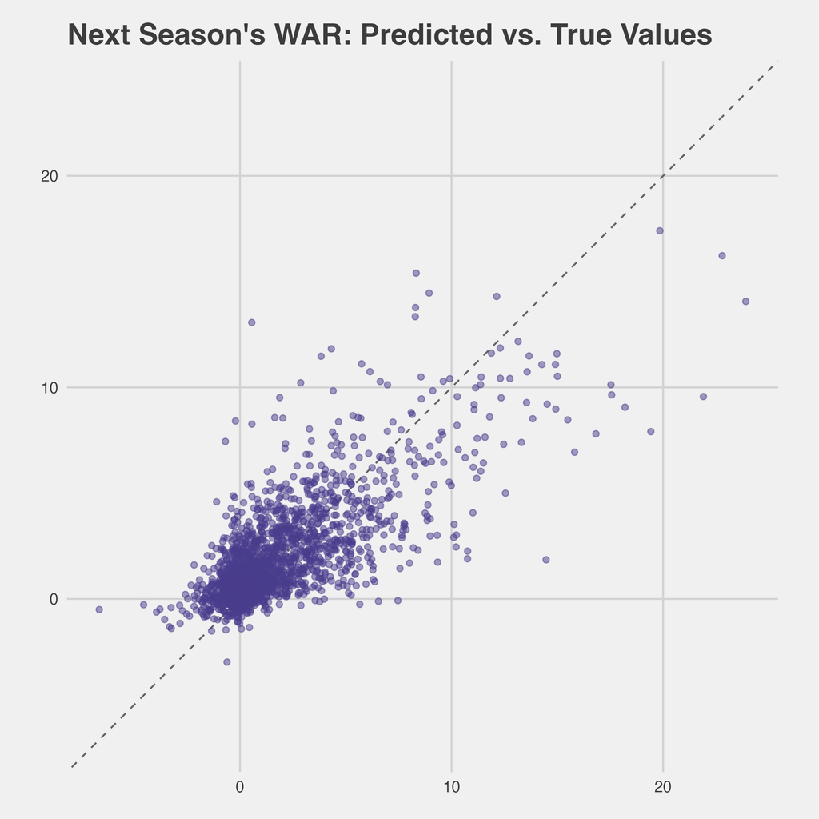

Figure 4: Predicted vs. True Values

## Conclusion

To quickly summarize: I took statistical and biographical data from NBA players by season between 1997 and 2021 to attempt to predict each player’s WAR (Wins Above Replacement) in the following season. I used 6 different models and 2 strategically targeted recipes (one at statistical indicators and another at biographical ones) to make this prediction. It turned out that a relatively basic linear model with an emphasis on biographical predictors performed best on the resampled training set of data, and applying it to the testing set actually improved its performance while providing some key takeaways. Overall, the model is not something I would apply to real-life use at this point, as the metrics from applying it to the testing set are not great.

The takeaways from the test results provide a couple implications for how I could improve the model in the future:

- More Predictors: This is a fairly straightforward one, but given most models had similar performance across both recipes, it seems clear that (at least in the linear case) we could see some marginal improvements with more predictors, assuming they are indicative.
- Better Indication for Elite Players: The model was scared to overestimate WAR for players with very high true WARs, so including an indicator for personal accolades such as awards or all-pro team selections could push the model to not be as timid.

## References

- Silver, Nate. “Introducing Raptor, Our New Metric for the Modern NBA.” FiveThirtyEight, FiveThirtyEight, 10 Oct. 2019, fivethirtyeight.com/features/introducing-raptor-our-new-metric-for-the-modern-nba/.

## Data Sources

[Advanced Metrics Raptor Data - FiveThirtyEight](https://github.com/fivethirtyeight/data/blob/master/nba-raptor/historical_RAPTOR_by_player.csv)

[Draft Data - Kaggle](https://www.kaggle.com/datasets/justinas/nba-players-data?resource=download)